# Virginia Math Bulletin

## View from the Chair

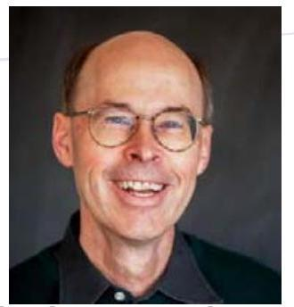

The Mathematics Department had an exciting 2014-15. Our new Institute of Mathematical Sciences began with a series of talks by distinguished mathematicians Alex Lubotzky in the Fall and Vaughan Jones in the Spring. We welcomed Yen Do and Leonid Petrov to the department this year as new Assistant Professors. We had an active season of hiring. Jennifer Morse will be joining us beginning in Fall 2016 as a Full Professor. Thomas Koberda was hired last year, and joins us in Fall 2015. We were fortunate to hire Paul Bourdon, who will become our new Director of Lower Division courses. He brings great experience, super teaching, new ideas and energy to our program. We also hired two postdocs: Aseel Farhat will be a new Whyburn Instructor, and Lloyd West joins us as a Postdoctoral Research Fellow in Fall 2015.

Not only was 2014-15 a time of transitions in the Mathematics Department, but across Grounds as well. Over last summer, the College of Arts and Sciences welcomed its new Dean, Ian Baucom. We are currently searching for a new Provost who will replace John Simon. John Hawley continues to be our Associate Dean overseeing science departments, including Mathematics.

We also had losses. Last summer Tom Kriete retired, and Mike Hill is leaving to take a professorship at UCLA. We will miss both of them greatly. Luckily, Tom is finishing a book and is in the department often. Sadly last Fall we had a devastating and unexpected loss of our friend and long-time staff administrator, Julie Riddleberger. Many of us from the department were able to attend her memorial service. Although her expertise and institutional memory was unmatched, we are very glad we hired Kimberly Lamal to replace her. We are also excited to welcome Damar Watts, who is in Connie Abell’s old position.

The next few years will be a busy time for the department with many new hires and a restructuring of our undergraduate program. Christian Gromoll spearheaded a year-long review of our undergraduate programs, culminating in a long report which details many improvements we will be implementing over the next few years.

Kerchof Hall has been undergoing improvements over the last few years, with office and hallway renovations. This summer, the entire front entrance is undergoing a major facelift and improvement. You may not recognize the building when it is done. This work will close our front entrance for most of the summer.

In this newsletter, you will find articles about some of the research our undergraduates are doing, about the successes of our faculty, and other news of the department. Tai Melcher was promoted to Associate Professor since our last newsletter; Andrei Rapinchuk became the new McConnell-Bernard Professor of Mathematics and was elected a Fellow of the American Mathematical Society; and Andrew Obus won an All-University Teaching Award. Congratulations to all of them!

Mathematics and the sciences in general are threatened by large cuts of National Science Foundation funding in both number and size for individual principal investigators. These cuts affect the department, and we are all the more grateful for the gifts of people who contribute to our general gift fund and endowment to allow us to sustain and improve our many activities. Thank you for your generosity.

Craig Huneke  
Marvin Rosenblum Professor of Mathematics

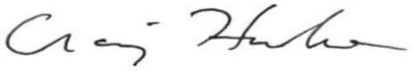

### Supporting Us

The Mathematics Department is grateful for the generous support of its alumni and friends. The Department welcomes gifts annually to address its most urgent needs, as well as to the endowment which provides funding in perpetuity. To learn about how you can make a difference by supporting the Mathematics Department, please contact Liz Blaine at lblaine@virginia.edu or (434) 924-6156. To make a gift online, please visit http://giving.virginia.edu/mathematics

## Department Transitions

### New Faculty Joining the Department of Mathematics

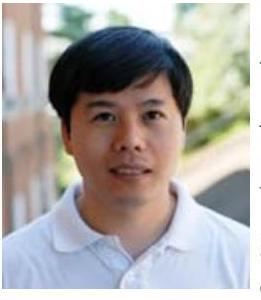

**Yen Do**  
*Assistant Professor*

Yen Do arrives at the University of Virginia following a three-year appointment at Yale University as a Gibbs Assistant Professor. At U.Va., Do will be focusing his research on harmonic analysis and its applications. Specifically, he is seeking to apply techniques from harmonic analysis to investigate research problems in mathematical physics and probabilistic analysis.

Do received his PhD from UCLA (2010) and held an NSF Mathematical Sciences Institute postdoctoral appointment at the Georgia Institute of Technology (2010-2011). He completed a bachelors of engineering at the University of Technology, Sydney in Australia (2005). He received an NSF grant (2012-2015) to support his work on Fourier analysis and its application to completely integrable systems.

This year, Do taught a course in calculus and a course in partial differential equations, while further developing his research program in analysis and probability.

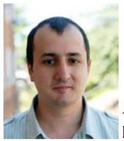

**Leonid Petrov**  
*Assistant Professor*

A Mathematician whose work brings together probability theory, representation theory and algebraic combinatorics, Leonid Petrov seeks applications for his research to mathematical physics.

Part of his work revolves around the mathematical side of the so-called Kardar-Parisi-Zhang equation, which originated in mathematical physics in the 1980s. The equation represents the effort to describe random "nonlinear" growth phenomena, such as random polymers, polynuclear growth models, bacteria colonies and metastable phases. Petrov and other mathematicians are investigating rigorous theories describing these phenomena employing specific tools based on exact combinatorial or algebraic identities.

Petrov arrived at UVa following a postdoctoral appointment at Northeastern University. Prior to that, he was a research associate at the Dobrushin Mathematics Laboratory in Moscow. Petrov received his PhD from the Institute for Information Transmissions Problems in Moscow (2010) and completed his undergraduate studies in probability at Moscow State University (2007).

Petrov will be collaborating with our research groups in probability, mathematical physics, and representation theory. This year he taught undergraduate courses on probability.

[figure not shown]

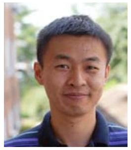

**Zezhou Zhang**  
*Whyburn Instructor*

Zezhou Zhang’s research interests include combinatorial and asymptotic aspects of group theory, nonassociative algebra and their interactions. Zhang is currently applying Lie and Jordan methods to enhance the understanding of certain groups.

He received his PhD in Mathematics from the University of California, San Diego last year and completed his B.A. in Mathematics at Peking University (2009). Most recently, his article, "Nonassociative Algebra and Group with Property (T)" was published in the International Journal of Algebra and Computation.

Zhang served as a teaching assistant for five years at UCSD and has delivered presentations on his work at UCSD and at the Erwin Schrödinger International Institute for Mathematical Physics in Vienna, Austria. He looks forward to collaborating with an active research group at U.Va.

Professor Tai Melcher has been promoted from Assistant to Associate Professor of Mathematics. Tai completed her PhD at UC San Diego in 2004 under the guidance of Bruce Driver. She then held a postdoctoral position at UC Berkeley, before joining the faculty at UVa.

Tai’s research is in heat kernel analysis, which studies the behavior of diffusions in various geometric regimes. The interplay between particle or heat diffusion and the geometry of the ambient space is well studied and largely well understood in the context of "nice" geometries. However, in certain (sometimes infinite-dimensional) physical models, the natural geometry is degenerate in some sense, and much less is known, particularly about the "smoothness" of diffusion in these spaces. Tai’s work intersects parts of probability, analysis, and geometry, with a primary goal of using probabilistic tools to understand the critical geometric quantities that allow smooth diffusion.

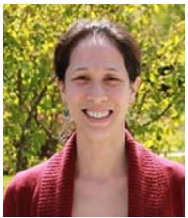

She directed the doctoral thesis of Daniel Dobbs (PhD 2013, currently an assistant professor at Huntington University) and is presently supervising Joshua Campbell in PhD research. Tai has been involved in a variety of projects with UVa undergraduates, including running REUs and organizing a “math and art” seminar as one of the 2013-14 UVa Mead Honored Faculty. She is also active in mathematics outreach at the local and international levels. Last year, she was one of two recipients of the AWM Service Award, which recognizes individuals for helping to promote and support women in mathematics through exceptional volunteer service to AWM. She also recently started the UVa Math Ambassadors program, which involves graduate students in community mathematics outreach, like visits to middle school classrooms, hosting booth activities at local school science days, and coaching math competitions like MATHCOUNTS. Tai also organized Women in Probability, which provides networking and mentoring opportunities for early career women researchers in probability.

### New Graduate Students

Christopher Leonard  
Mark A. Schrecengost  
Mark Lewers  
Huy Dang  
Johnathon Upperman  
Matthew Feller  
Bogdan Krstic  
Liaosha Xu

## New Institute of Mathematics

The Institute of Mathematical Sciences is a new structure in the Department of Mathematics. Its mission is to promote mathematical research and education. One of the goals is to provide additional opportunities for research collaboration between our faculty and mathematicians from other universities and thereby increase the visibility of our department as an institution of mathematical research. Another goal is to enhance the role of the department as a center of mathematical education in the university and the community. The IMS will conduct a broad range of activities that will include thematic programs and semesters, workshops, lectures by distinguished mathematicians and public lectures for general audience. The IMS is supported by a 5-year grant from the Dean of Arts and Sciences.

Last year, the IMS established the Distinguished Lecture Series “Virginia Mathematics Lectures.” The inaugural speaker was Professor Alex Lubotzky from the Hebrew University of Jerusalem. In his lectures Expanders: From One-dimensional to Multi-Dimensional (November 18-20, 2014), Lubotzky gave an overview of the theory of expander graphs (which are highly connected graphs that play an important role in pure and applied mathematics and computer science), discussed its connections with many other areas of mathematics including group theory, number theory and representation theory, and reported on the ongoing effort to extend the theory to higher-dimensional simplicial complexes. The second series of lectures (April 6-8, 2015) was given by the Fields medalist Vaughan Jones (Vanderbilt University). In his first lecture, Jones surveyed knot theory to which he had made fundamental contributions by introducing very important invariants of knots currently known as Jones polynomials and described connections between knots, braids and group theory. The second lecture was about von Neumann algebras and how these arise in physics. In the third lecture, Jones showed how the notions from knot theory and the theory of von Neumann algebras together provide an insight into the problems of Conformal Field Theory. Both lecture series were enthusiastically received by the audience, which included undergraduate and graduate students, faculty members and guests from other departments and institutions. Given the success of the lectures, the IMS will organize two such series every year. The speakers in AY 2015-16 will be Ian Agol (UC Berkeley) in the Fall, and Karen Smith (University of Michigan) in the Spring.  
The IMS also organized a public lecture by the popular mathematics speaker Professor Art Benjamin (Harvey Mudd College). He works in combinatorics and has authored five books and about 90 papers. He filmed several sets of lectures for the Great Courses series. But he is also known for his dazzling “Mathemagic” performances at different venues; he was featured on the Colbert Report, in the New York Times, USA Today, People’s Magazine, and Scientific American. His performance at UVa gathered an audience of more than 200 people from the university and the community including at least 50 middle and high school students.

The IMS has also sponsored thematic programs in representation theory, PDEs and harmonic analysis as well as partially sponsored the Mid-Atlantic Topology Conference.

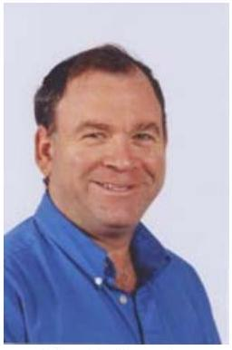

Alex Lubotzky

Alex Lubotzky is the Maurice and Clara Weil professor of mathematics at the Hebrew University of Jerusalem and a professor at Yale University.

Lubotzky has authored 4 books and more than 130 research papers, many of which appeared in such leading mathematical journals as the Annals of Mathematics, Inventiones Mathematicae, Journal of the American Mathematical Society, Acta Mathematica, and others. He was an invited speaker at the International Congress of Mathematicians in Zurich (1994). Lubotzky is a recipient of numerous grants and prizes, including the famous Erdős prize. He is a member of the Israeli Academy of Sciences and Humanities and a foreign member of the American Academy of Arts and Sciences. In 1996-1999 he was a member of the Israeli Knesset.

The mathematical contributions of Lubotzky are spread across several areas, including group theory, discrete mathematics, interactions between these areas and number theory, the theory of lattices in algebraic and Lie groups. He was one of the founders of the theory of expander graphs that plays an important role in computer science. In his lectures he described the new frontiers of this theory as it evolves from one-dimensional to multi-dimensional.

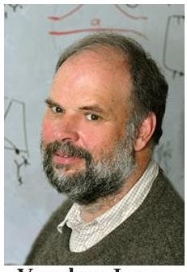

Vaughan Jones was an undergraduate at the University of Auckland, from where he obtained a BSc in 1972 and an MSc in 1973. He completed his PhD at the University of Geneva in 1979. In 1980, he moved to the United States, where he taught at the University of California, Los Angeles (1980-1981) and the University of Pennsylvania (1981-1985), before being appointed as Professor of Mathematics at the University of California, Berkeley. Jones is currently on the faculty of Vanderbilt University as a distinguished professor of mathematics.  
His work on knot polynomials, with the discovery of what is now called the Jones polynomial, was from an unexpected direction with origins in the theory of von Neumann algebras, an area of analysis already much developed by Alain Connes. It led to the solution of a number of the classical problems of knot theory, and to increased interest in low-dimensional topology. He was awarded the Fields Medal in 1990 and became a Fellow of the Royal Society in the same year.  
As of January 2015, he is a vice-president of the International Guild of Knot Tyers.

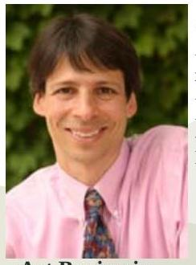

Art Benjamin

On March 23, 2015, in an entertaining and fast-paced performance, Dr. Art Benjamin entertained many as he showed the public how to mentally add and multiply faster than a calculator, improve their memory for numbers and determine the day of the week for any date in history.

## Student Honors

### 2015 Undergraduate Prize Winners in Mathematics

### Edwin E. Floyd Prize in Mathematics

The 2015 Edwin E. Floyd Prize in Mathematics was given to Alexander Grieser, Jiahua Liu, Yongyi Wu and Bradley Zykoski. The prize is awarded to second- or third-year students who show exceptional promise in mathematics.

### William Lowell Putnam Mathematical Competition Award

The 2014 William Lowell Putnam Mathematical Competition Award was given to Robert Jacobs for his outstanding score on the exam. Congratulations to the entire team.

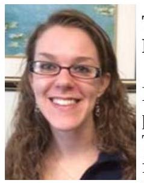

### The Dr. Frank Finger Graduate Fellowship for Teaching

Katelynn Kochalski won the Department of Mathematics Graduate Teaching Award in Mathematics for 2014. She went on to win the University-wide Frank Finger Graduate Fellowship for Teaching.

[figure not shown]

Five Majors have been elected into Phi Beta Kappa

Danielle Jones  
Megan Tracy  
Anna Yanchenko  
Ziyuan Jin  
Siyao Chang

As the oldest and most distinguished honor society in the country, Phi Beta Kappa offers membership to less than one percent of all undergraduates. Many of the leading figures in American history and culture have begun their careers with election to the society, including seventeen presidents of the United States. As a result, membership is a remarkable accomplishment, both for the student who achieves it and the faculty and staff whose support and guidance has led to this milestone.

[figure not shown]

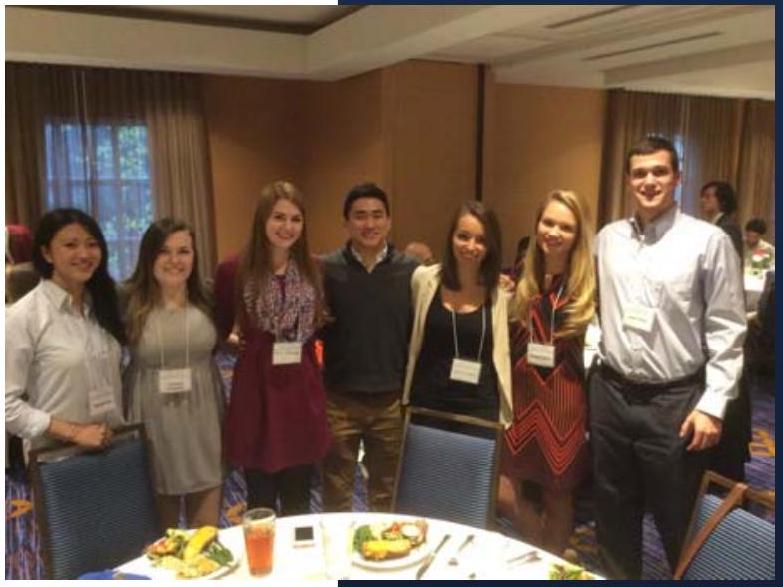

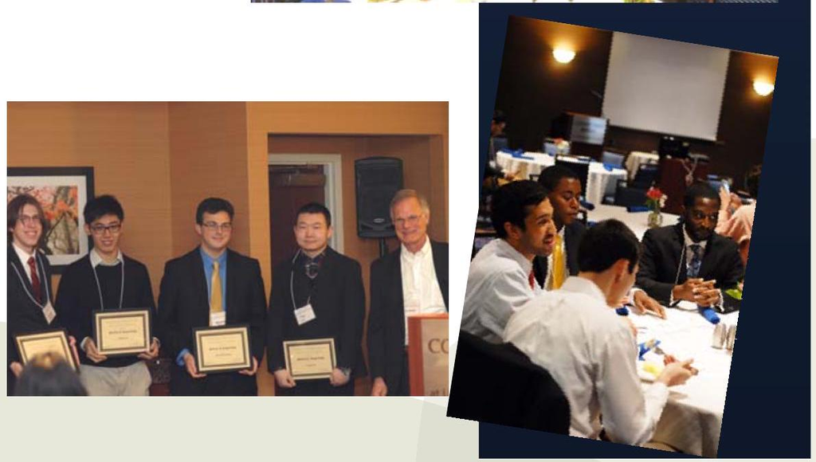

## Spotlight on Undergraduates

### Interview

In October, Calvin McPhail-Snyder (4th year) and Tahseen Rabbani (4th year) conversed about research and mathematics with Craig Huneke and Damar Watts. Calvin has been working with Christian Gromoll on modeling how honey bees swarm to find new locations, while Tahseen worked with Andrew Obus on a classical problem of representing integers by quadratic forms. See the descriptions of their projects below. Both intend to go on to Graduate School in Mathematics.

**CH: What is your background? How did you first get interested in mathematics?** Tahseen: I’m from Richmond. I applied to and attended Henrico High School, in one of the alternative programs offered there, the International Baccalaureate Program (IB). The program not only has the usual workload of high school, but has a unique curriculum focused on developing analytical thinking and writing skills, with an emphasis on studying differing cultural perspectives. I was originally interested in Biology, but an IB class in single-variable calculus my senior year was inspiring, and forced me to rethink. The creativity needed to do serious mathematics is very satisfying. Still, I didn’t change my major to mathematics until my 2nd year at UVa.

Calvin: I’m from Arlington. I attended H-B Woodlawn, which is an alternative magnet high school program. I’ve always been interested in math, but I did get somewhat bored by my high school math courses, and turned to the web for more information. For instance, I self-taught myself group theory.

In my sophomore and junior years I got a lot out of the Princeton Companion to Mathematics, a fantastic book. I recall an article by Terry Tao about integration which really opened my eyes. I am in the College Science Scholars program, and as part of that program, one must begin a research project, so I very naturally was looking for possible topics.

**CH: What do you like best about math? Some people think of mathematicians as very isolated, working alone, seeking that “AhHa!” or “Eureka” moment. Others prefer to collaborate in groups. How do you think about research in mathematics?**

Calvin: Groups are great to work within because of the collaborations. Working with others enables you to pool your ideas and see problems from different perspectives. In a group situation, you can combine a variety of skills and expertise to tackle more complex and larger scale problems. If proofs are hard, then that just means there is more to discover. On the other hand, working by myself allows me to figure out problems, by being able to independently dissect the problem to come to an independent conclusion.

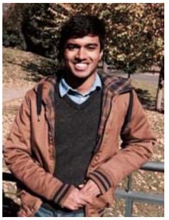

Tahseen Rabbani

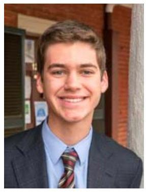

Calvin McPhail-Snyder

Tahseen: I like that Mathematics is very unified. Something you learn on one topic can often be transported to another part of mathematics. Groups can be good – what you may have been working on by yourself to solve can more easily be accomplished in a short amount of time, and you learn from your peers. I do like to work individually as well. It helps me to internalize the practice and the teaching I have learned, and to figure out proofs myself. I do not really get the "AhHa!" moment. I get more of a satisfaction of learning and using the methods to figure out difficult solutions to complex problems.

**CH: How has research enriched your education?** Tahseen: I have found that putting theory into practice gives more meaning to coursework – rather than learning for the sake of learning, I am learning for the sake of "doing." I now see my education as a means by which to pursue interesting and varied topics of research.

Calvin: I think research has given me a much better appreciation of how to use techniques to approach "real-world" problems. It’s interesting to see how to use a method on a problem you encounter in research, as opposed to one from a textbook.

**CH: What do you do to relax? Do you have hobbies or activities you like to do?**

Calvin: I’m a member of the Jefferson Literary and Debating Society. (Editor Note: this society was founded on July 14, 1825. Calvin joins the ranks of past members like Edgar Allan Poe, and the 28th President of the United States Woodrow Wilson). I also play ultimate Frisbee.

Tahseen: I play soccer for a local team called the "Honey Badgers". I also enjoy trying different restaurants around the area. I like the Downtown Grille and Bellas. But I have a vigorous course schedule and work hard on academics.

### Interview Continued

**CH: How do you feel about the experience provided to you at UVa?** Calvin: I have generally enjoyed my time at UVA; I think it’s a very good place to focus on academics without prioritizing them above everything to an unhealthy extent.

Tahseen: One of the most distinguishing aspects of the Mathematics department is the incredible amount of support the professors are willing to offer. I have met personally with many of my professors and they have always been interested in the work I’m doing. Their advice has allowed me to refine my research interests and achieve the goals I have set for myself from the beginning of my undergraduate career. I owe a great deal of my success as Mathematics major to the faculty’s excellent guidance.

[figure not shown]

### Undergraduate Research

Calvin McPhail-Snyder has been modeling honeybee swarms with Christian Gromoll. Honeybee swarms have a democratic mechanism for choosing a nesting site; they combine the site preferences of many individual bees to quite reliably choose the best site. However, they can’t perform a straight vote. Instead they use a cascading recruitment process to form competing teams, each advocating for a different site. The best site usually gives rise to the winning team. In the biology literature, the success of this mechanism is claimed to derive from a sort of law of large numbers, in which the average of many bees’ preferences should always find the best site. But the bees can’t actually compute this average, which would be a straight vote. So the observed success of their cascade system must be explained differently, by modeling it as a mathematical branching process estimator. The basic question is: does this branching process estimator have the same properties as a theoretical straight-vote average, as claimed in the biology literature?

Calvin has created some fascinating simulations that seem to uncover something new: the claims made in the biology literature, while true in some parameter regimes, can fail in certain other parameter regimes. That is the branching process estimator behaves differently from the straight-vote in some situations. Calvin and Christian are in the process of turning this fact into a theorem with proof. The plan is to then publish a joint paper.

Tahseen Rabbani embarked on a research project on the topic of representation of integers by quadratic forms, working with Andrew Obus. A major classical result in this field is Lagrange’s theorem from 1770, stating that every natural number can be represented as a sum of four squares. More generally, one can study positive definite integer-matrix quadratic forms $Q$, which are homogeneous degree two polynomials in many variables with integer coefficients, such that the cross terms (i.e., the terms not coming from the square of one of the variables) have even coefficients, and such that the form only takes positive values when nonzero integer entries are substituted. For example, $Q$ could be $x^{2}+y^{2}+z^{2}+w^{2}$ (the four squares form) or $x^{2}-2xy+3y^{2}$. Tahseen’s research investigates the question of forcing. A prototype of a forcing theorem is the famous theorem of Conway-Schneeberger from 1993 that if a form $Q$ as above represents all of the numbers from 1 to 15, then it must represent all natural numbers. So in order to check that every natural number is the sum of four squares, one need only check the numbers 1 through 15! Tahseen investigated the forcing relation in detail. In particular, he studied the question of minimal forcing sets. That is, given some natural number $n$, is there a smallest subset $S$ of $1, \ldots, 15$ such that if a form $Q$ as above represents $S$, then it represents $n$? Tahseen showed that infinitely many natural numbers have no unique minimal forcing sets.

## Whyburn & the Modern Department

### “Getting One’s Hands Dirty”: An Adventure in the Papers of Gordon T. Whyburn

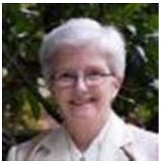

Karen V. H. Parshall  
Professor of History and Mathematics

Mathematicians have long used the phrase "getting one’s hands dirty" when talking, for example, about slogging through a series of examples in order to gain insight into what a theorem should be. That phrase, however, most definitely pertains to historians of mathematics, too.

Everyone familiar with the history of the Department will know the name Gordon T. Whyburn. Influential twentieth-century American topologist and member of the National Academy of Sciences, Whyburn was a "force of nature" at the University from 1934—when he was hired to transform UVa’s Department of Mathematics from a sleepy Southern backwater into a major research department—to his death at the young age of sixty-five in 1969. It was Whyburn’s role in the history of American mathematics especially between the two World Wars—the topic of my current book-length research project—that took me to UVa’s Department of Special Collections over the summer of 2014.

I knew that Whyburn’s family had deposited his papers in the archives there, and I hoped that his Nachlaß might shed light on some of the questions that have arisen during the course of my research thus far. On searching UVa’s online catalogue, though, I found a puzzling remark. The collection was in eleven "cubics." Scratching my head, I e-mailed the Head of Reference and Research Services in Special Collections to ask her what that meant exactly. I could almost hear the sigh in her reply: "It means that the collection has been unprocessed and is currently in eleven very large, uncatalogued boxes."

After spending two days literally going through each box folder by folder, document by document just to get a sense of what was there, I realized that the collection contained amazing material. An historian’s dreams come true! The only problem was ... how to use it in its totally unorganized state? Thinking on that question for a couple of days, I, with more than some trepidation, approached Special Collections with a proposition: would they consider allowing me full access to the collection for a semester to put order into it so that I could actually use it in my work. After just a couple of days, the answer came back as “yes!”

What a mass of material I confronted! There were letters between Whyburn and some of the other giants of twentieth-century topology, among them, Kazimierz Kuratowski of the Polish school and Solomon Lefschetz and Robert L. Moore of the two opposing American schools. There was rich documentation on the American Mathematical Society (AMS) during and immediately after the Second World War, and especially in 1953 and 1954 when Whyburn served as AMS President. There was fascinating correspondence about the University’s decision to hire Whyburn and about the mechanics of creating a research department of mathematics from scratch, in the South, and in the depths of the Depression of the 1930s. Only archives have the potential to answer such thorny historical questions, but, as my experiences over the fall semester of 2014 attest, it can be literally true that historians have to “get their hands dirty” in the archives!

### George Dyson: From Analog to Digital and Back!

On April 9th, 2014, the Departments of Mathematics, Computer Science, and History jointly sponsored a public lecture entitled "From Analog to Digital and Back: The View from 1946" by historian of science George Dyson.

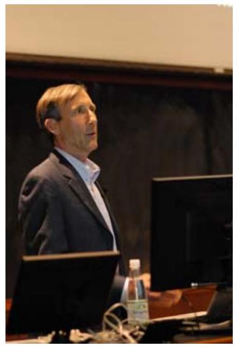

The talk was based on Mr. Dyson’s 2012 New York Times best-seller "Turing’s Cathedral", describing the personalities, engineering, and social forces behind the rapid development of computers in the mid-20th century.

Math professor emeritus Leonard Scott said it was "the best talk of this type that I have ever seen."

Here is the abstract of Mr. Dyson’s talk:  
"Alan Turing’s one-dimensional model of universal computation of 1936 led directly to John von Neumann’s two-dimensional implementation of 1946.

The resulting address matrix, entrenched for 60 years, is how the machines are able to find the codes, and how the codes are able to find the machines.

Where to from here? Some 3.5 billion years ago, analog organisms adopted digital coding to facilitate replication, error correction, and modification of instructions from one generation to the next. Are we really destined for all digital all the time, or will analog supervene?"

## Faculty Honors

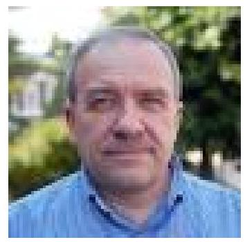

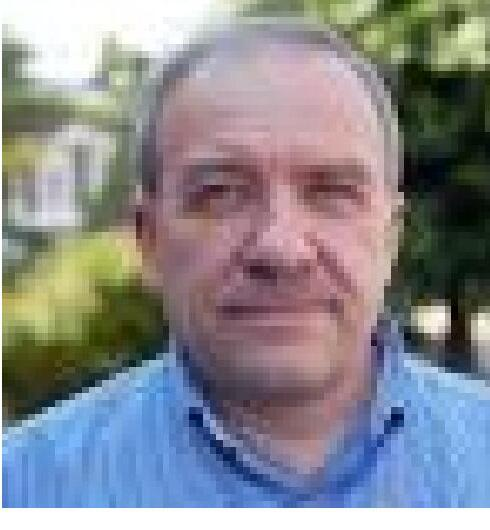

Professor Andrei Rapinchuk of the Department of Mathematics was among 63 mathematical scientists from around the world honored recently as part of the 2015 class of Fellows of the American Mathematical Society. Now in its third year, the AMS program recognizes members who have made outstanding contributions to the creation, exposition, advancement, communication, and utilization of mathematics. Prof. Rapinchuk was named an AMS Fellow for his contributions to the arithmetic theory of algebraic groups and geometry of locally symmetric spaces. With his appointment, the College’s Department of Mathematics now features seven AMS Fellows: Ira W. Herbst, Craig Huneke, Brian J. Parshall, Karen Hunger Parshall, Loren D. Pitt (emeritus), Andrei Rapinchuk, and Leonard L. Scott (emeritus).

Also, earlier this fall, Prof. Rapinchuk was appointed the University’s new McConnell-Bernard Professor of Mathematics, a chaired professorship.

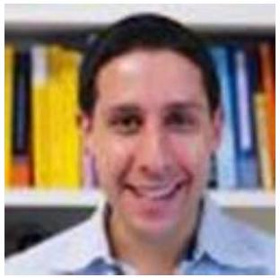

### Andrew Obus Received the All-University Teaching Award for 2014–2015

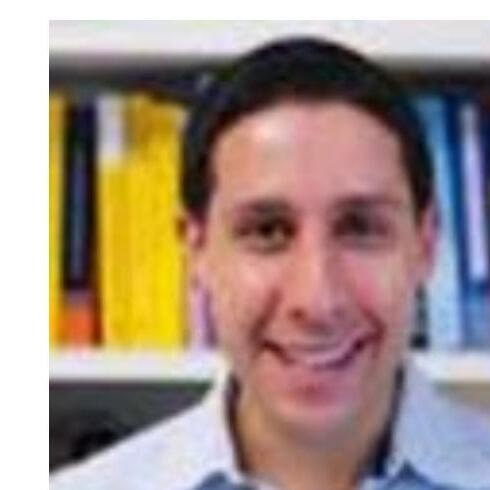

Professor Andrew Obus was chosen to receive this award along with eight (8) other recipients for their excellence in teaching, research and service accomplishments. He is remarkable for his contagious enthusiasm, meticulous preparation, and his near perfect student evaluations.

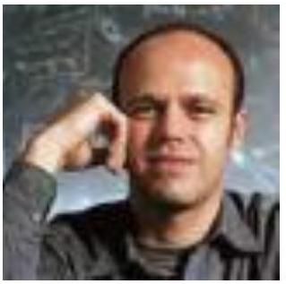

### Slava Krushkal Was Awarded a Prestigious Simons Fellowship for the Fall Semester, 2014

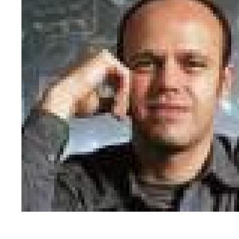

The Fellows Programs provide funds to faculty for up to a semester long research leave from classroom teaching and administrative obligations. Such leaves can increase creativity and provide intellectual stimulation. The goal of the Simons Fellows Program is to make it easier to take such leaves, or to extend sabbatical leaves by an extra half year.

## The Wave Project

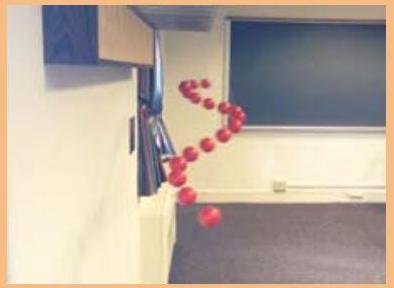

Like the design of other pendulum wave machines, this one is primarily based on the original published by Richard Berg [Am J Phys, vol. 59, 1991] and popularized by the Harvard Natural Sciences Lecture Demonstrations. Such constructions are typically freestanding; the Math in Place model was inspired by the wall-mounted version created by artist Kim Bernard for her exhibit “Stuff Moves”.

The basic mechanism is as follows: The period of one complete cycle is 60 seconds. The length of the longest pendulum has been adjusted so that it executes 40 oscillations per cycle, and the length of each successive pendulum is adjusted so that it completes one additional oscillation per cycle. Thus, if all pendulums are begun initially in phase (that is, starting at the same maximum amplitude), then they will all come back in phase again at precisely the end of one cycle. In the meantime, one can observe sine waves, interweaving sine waves, beating, and otherwise seemingly periodic motion.

A pendulum wave machine generates a traveling wave, whose displacement at position $x$ and time $t$ can be represented by the function $f(x, t) = A \cos((ax+b)t)$ where $A$ is the maximum amplitude and $a$ and $b$ are some fixed constants depending on the construction. So one can see that, as time progresses, the wave has increasingly smaller wavelengths. Despite this, the motion of the pendulums seems periodic, because we are only observing the wave at certain fixed positions. Remember, there are (infinitely) many sine waves that pass through a specified point! This effect or illusion is known as spatial aliasing.  
See the video [ctrl+click].

## Recent PhDs

### May 2015

**Arindam Banerjee**  
Advisor: Craig Huneke  
Title: Castelnuovo-Mumford Regularity And Edge Ideals

**Huanchen Bao**  
Advisor: Weiqiang Wang  
Title: Canonical bases arising from quantum symmetric pairs and Kazhdan-Lusztig theory

**Ilya Smirnov**  
Advisor: Craig Huneke  
Title: Uniform convergence methods in Hilbert-Kunz theory

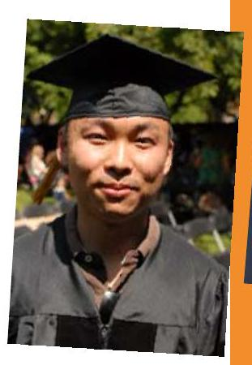

### August 2014

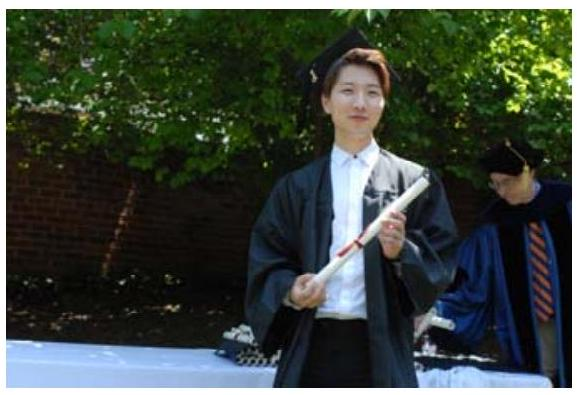

**Reed Nessler**

Advisor: Peter Abramenko  
Title: Simple Connectivity in Polar Spaces with Group-Theoretic Applications

**Daniel Stephen ReMine**

Advisor: Roberto Triggiani  
Title: Analysis and Computational Fluid Dynamics for the Stabilization and Control of 3-Dimensional Navier-Stokes Fluid Channel Flows by a Wall-Normal Boundary Controller

**Julia Catherine Spencer**

Advisor: Roberto Triggiani  
Title: Min-Max Game Theory for the Linearized Navier-Stokes Equations with Internal Localized Control and Distributed Disturbance

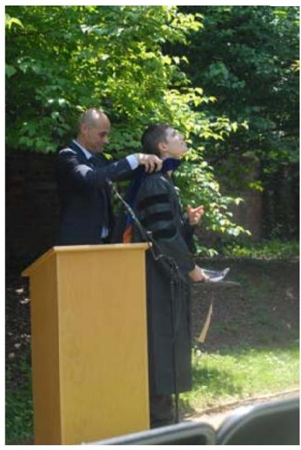

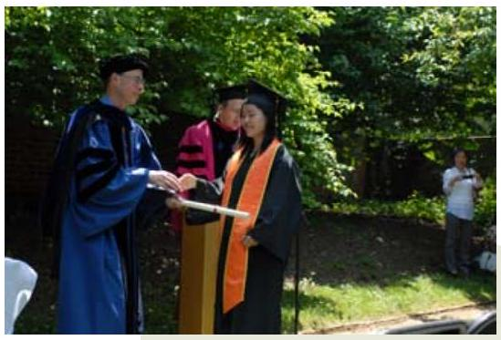

[figure not shown]

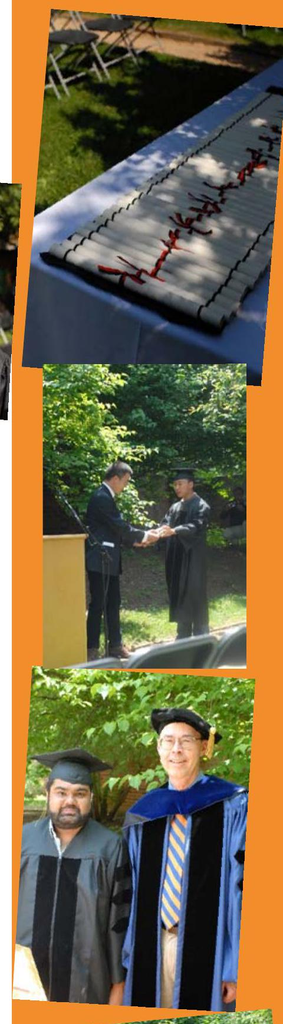

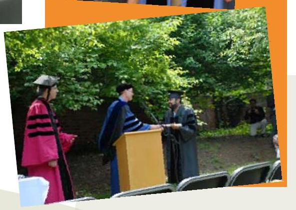

## Spotlight on Alumni

Arthur (Art) Roselle, partner at Pamlico Capital, and U.Va. math alumnus and McShane Prize winner in 1992, came to speak to the Undergraduate Math Club on March 23, 2014. The meeting had a record attendance of over 25 students, including many first-time participants.

Mr. Roselle spent the first part of the talk discussing his background as a math major and Master’s student, and then spent the second half talking about his career in private equity, and how he regularly puts into use the mathematical habits of mind he developed during his U.Va. education.

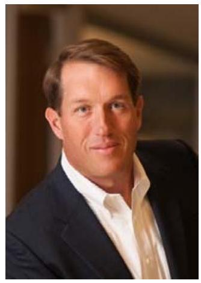

He made a compelling argument that the training received as a math major is extremely valuable.

As he put it, “The mathematics that I took at UVa has been an important part of my life, not so much for its direct application (I am not in quantitative research or anything like that), but for how it taught me to approach problems.” The meeting ended with a question and answer session, where students asked questions on topics ranging from the state of private equity today to Mr. Roselle’s favorite math class.

### Gordon E. Keller Math Majors Dinner Speaker

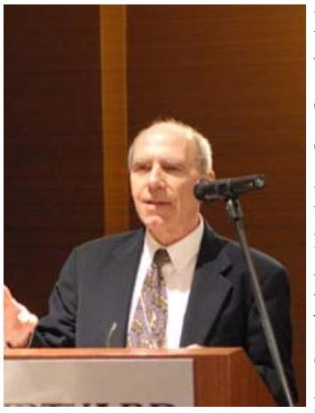

Dr. Douglas Costa, Director of Quantitative Research, SIG, LLP, gave the after dinner talk at the annual Math Majors dinner.

Dr. Costa received a B.A. in Mathematics from Oberlin College in 1968, and completed a Ph.D. in Mathematics at the University of Kansas in 1974, specializing in Commutative Algebra. He then joined the faculty of the mathematics department at the University of Virginia, where he worked until 1997. In 1997, Dr. Costa joined Susquehanna International Group, LLP, in Bala Cynwyd, Pennsylvania, as Director of Quantitative Research. His talk focused on the “unreasonable” effectiveness of mathematics, and why it is so valuable. We were delighted to have him come back to UVa. He and his wife Laurel have provided generous support for our Math Majors Dinner in honor of our former colleague, Gordon E. Keller.

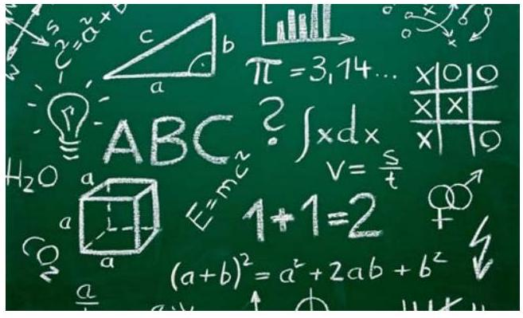

## The Problem Corner

1. Suppose that every undergraduate at UVa counts the number of other undergraduates with whom he or she has taken a class. Prove that some pair of students will get the same number.
2. Prove that every positive integer cube can be written as the difference of two perfect squares.
3. One hundred people board a plane, which has exactly 100 seats; each has an assigned seat. The first passenger lost his seat assignment and sits in a random seat. Subsequently each passenger either sits in their assigned seat, if it is available, and if not chooses a random seat. What is the probability that the last person boarding will sit in their assigned seat?

## What Are You Doing?

We’d like to hear from you!  
You may complete the form below and return it to us:  
Form [ctrl+click]: http://pi.math.virginia.edu/ questionnaire.pdf

Facebook [Ctrl+click]: https://www.facebook.com/UVAMath

FAX: 434-982-3084  
Email: math-help@virginia.edu  
Department of Mathematics  
University of Virginia  
P. O. Box 400137

Charlottesville, VA 22904-4137